# **Twitch // SMM's Tutorial, by Davide Casano (X81000862)**

[figure not shown]

# **Introduction**:

## What is Twitch? Why should we analyze this platform?

*Twitch.tv* is a livestream platform where people have the chance to discover different types of topics. Founded in 2011 and now owned by *Amazon.com, Inc.* it is mainly used to entertain and divulge digital content that can be viewed either live or on demand. With an average of 26.5 million daily visitors (2020, [Twitch](https://www.twitch.tv/p/press-center/)), Twitch is a web service and a global community where users have the opportunity to learn new skills, discover new artists, spend free time and more.

## Some stats:

- Acquired in a 2014 bidding war with *Google* for \$970 million, the company currently has an estimated net worth of \\$15 billion, 10 times more its purchase value (2020, [CNBC](https://www.cnbc.com/2020/06/16/amazon-media-assets-worth-500-billion-almost-as-much-as-aws-needham.html#:~:text=To%20get%20to%20%24500%20billion,says%2C%20is%20worth%20%24127%20billion)).
- With an average of 2 million viewership at any given moment (2020, [Twitch](https://www.twitch.tv/p/press-center/)), Twitch has more active users than the US networks CNN, Fox News, MSNBC and ESPN (2018, [Business Insider](https://www.businessinsider.com/twitch-is-bigger-than-cnn-msnbc-2018-2?IR=T)).
- Twitch remains far away the leader in streaming with 73% of the market share, but it’s being chipped away by YouTube (21%), Mixer (3%) and Facebook (3%), all of which have signed major streamers away from Twitch (2020, [Forbes](https://www.forbes.com/sites/mattperez/2020/01/08/report-amazons-twitch-not-meeting-ad-revenue-expectations/?sh=4982c0617164)).
- According to The Wall Street Journal, Twitch covers more than 1.8% of the US web traffic (2014, [The Wall Street Journal](https://www.wsj.com/articles/SB10001424052702304851104579361201655365302))

# **API Access**:

## Registration, API Key, API Secret:

1. Firstly, click on the specific link. Then, on the voice "Login with Twitch".

   > link: https://dev.twitch.tv/login

[figure not shown]

1. Secondly, log in.

[figure not shown]

   NB: The 1st and 2nd step can be reversed. If you are already logged in, you can ignore this (2nd) step.
1. Thirdly, read and agree the *Twitch Developer Services Agreement*. Then, click below on the voice "Autorize".

[figure not shown]

1. Now, this is what should come out:

[figure not shown]

1. To create the Application, click (below "Console") on "Applications". Then, on the right, on the voice "Register Your Application".

[figure not shown]

1. Fill the required information and click below on the voice "Create".

[figure not shown]

1. Now, the Application is created. In order to get the Application's *Client ID* and *Client Secret*, click on the voice "Manage".

[figure not shown]

1. Here there are the *API Key* and the *API Secret*:

[video not shown]

   NB: this information must be kept and not shared with anyone.

# **API REST**:

## Usage, description and examples:

REpresentational State Transfer (**REST**) refers to a group of software architecture design constraints that bring about efficient, reliable, and scalable distributed systems. A system is called RESTful when it adheres to those constraints.  
To access certain data about users’ accounts we have to choose one specific authentication method: **OAuth**. We use some parts of the OAuth 2.0 protocol.

Authentication involves:

1. **Registering your app** to obtain a client ID and client secret.
2. **Getting a token**. It includes permissions that your app requires.
3. **Sending the token in your API request** to authenticate API requests.

Notes:

- to look up the full official documentation, you can follow this link: https://dev.twitch.tv/docs/authentication
- to watch all the API official Reference, click here: https://dev.twitch.tv/docs/api/reference

Considered that the 1st point is already completed, let's complete the 2nd and the 3rd points: **getting the token** and **sending the token in your API request**.

```python
# import the required libraries to work with Python

import urllib.request, requests, json

CLIENT_ID     = "agtcjzo944zzlpydvr19ckyqxxhvb6"
CLIENT_SECRET = "77ypkhyf7uzkddi6j8lc856yahwkxh"

# make the request
def make_request(URL):
    header    = {"Client-ID": CLIENT_ID, "Authorization": f"Bearer {get_access_token()}" }

    req  = urllib.request.Request(URL, headers=header)
    recv = urllib.request.urlopen(req)

    return json.loads(recv.read().decode("utf-8"))

# get the token
def get_access_token():
    x = requests.post(f"https://id.twitch.tv/oauth2/token?client_id={CLIENT_ID}&client_secret={CLIENT_SECRET}&grant_type=client_credentials")

    return json.loads(x.text)["access_token"]

print("Access token: " + get_access_token())
```

```
Access token: otajx7guutg58p9q0xpel1r24ne39j
```

We got the *access token*. Let's make a couple of **examples** using **Twitch's REST API**:

```python
# 1st example: starting from a list of streamers,
# get the current online streamers list and print their current type of content

def get_current_online_streams():
    streamers  = [
        "emalloru",
        "rovazzi",
        "marcomontemagno",
        "jakidale",
        "chess24",
        "abracadabra",
        "enkk",
        "velox",
        "marcocrepaldi",
        "veritas"
    ]

    URL            = "https://api.twitch.tv/helix/streams?user_login="
    resps          = []

    for name in streamers: resps.append(make_request(URL + name))

    # bolding the online streamers
    bold      = "\033[1m"
    normal    = "\033[0m"

    GAME_URL = "https://api.twitch.tv/helix/games?id="
    for i, r in enumerate(resps, 0):
        if r["data"]:
            game_id   = r["data"][0]["game_id"]
            game_resp = make_request(GAME_URL + game_id)
            game_name = game_resp["data"][0]["name"]
            print("- " + bold + streamers[i] + ": " + game_name)

        else: print("- " + normal + streamers[i] + ": now offline")

get_current_online_streams()
```

```
- emalloru: now offline
- rovazzi: now offline
- marcomontemagno: now offline
- jakidale: now offline
- chess24: Chess
- abracadabra: now offline
- enkk: now offline
- velox: now offline
- marcocrepaldi: now offline
- veritas: now offline
```

```python
# 2nd example: starting from a list of streamers,
# get the first 10 popular categories of streams

def get_current_top_streams():
    URL         = "https://api.twitch.tv/helix/games/top"
    request     = []
    top_streams = []

    request.append(make_request(URL))

    # printing the top 10
    data = request[0]["data"]
    for i, r in enumerate(data[0:10], 1): print("{}. {}".format(i, r["name"]))

get_current_top_streams()
```

```
1. Just Chatting
2. League of Legends
3. Counter-Strike: Global Offensive
4. Grand Theft Auto V
5. Path of Exile
6. VALORANT
7. Fortnite
8. Dota 2
9. Apex Legends
10. Minecraft
```

# Third-party API:

## Usage, description and examples:

A *wrapper function* is a subroutine (another word for a function) in a software library whose main purpose is to call a second subroutine or a system call with little or no additional computation. Wrapper functions are used to make writing computer programs easier by abstracting away the details of a subroutine's underlying implementation.  
**TwitchAPI** is a full implementation of the Twitch API, its Webhook and PubSub in Python 3.7.

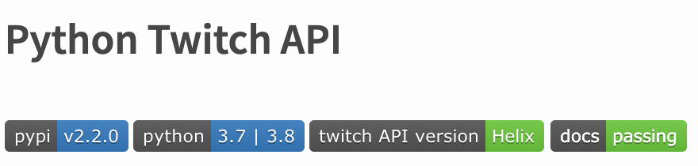

> To see the full official documentation click [here](https://pytwitchapi.readthedocs.io/en/latest/index.html).

It is very simple to install that using *pip*:

```python
# pip install twitchAPI

from twitchAPI.twitch import Twitch
from pprint import pprint
```

To see how wrappers increase readability and clarity of the code, relook:

1. **Authentication** and how to get the **access token**.
2. The 2nd **example** made.

```python
twitch = Twitch(CLIENT_ID, CLIENT_SECRET)

# let's create a simple app authentication:
twitch.authenticate_app([])

# get the access token
print("access token: " + twitch.get_app_token())
```

```
access token: zjrkfkh3ikyyn44y4p980xrhqtje5s
```

```python
# 2nd example: starting from a list of streamers,
# get the first 10 popular categories of streams

top_ten = twitch.get_top_games(None, None, 10)

for i in range(10): print("%d. " % (i+1) + top_ten["data"][i]["name"])
```

```
1. Just Chatting
2. League of Legends
3. Counter-Strike: Global Offensive
4. Grand Theft Auto V
5. Path of Exile
6. VALORANT
7. Fortnite
8. Dota 2
9. Apex Legends
10. Minecraft
```

We can also display this ranking in a different way, with *pandas* library:

```python
# pip install pandas
import pandas as pd

stats = []
for i in range(10):
    name = top_ten["data"][i]["name"]
    category_id = top_ten["data"][i]["id"]
    stats.append([name, category_id])

# create a new dataframe
df = pd.DataFrame(stats, columns=["name", "ID"])
df.index += 1

df.head(10)
```

|  | name | ID |
| --- | --- | --- |
| 1 | Just Chatting | 509658 |
| 2 | League of Legends | 21779 |
| 3 | Counter-Strike: Global Offensive | 32399 |
| 4 | Grand Theft Auto V | 32982 |
| 5 | Path of Exile | 29307 |
| 6 | VALORANT | 516575 |
| 7 | Fortnite | 33214 |
| 8 | Dota 2 | 29595 |
| 9 | Apex Legends | 511224 |
| 10 | Minecraft | 27471 |

```python
# 3rd example: starting from a video ID
# get the streamer's ID and information about its stream

videoID = "965206441"
userID = twitch.get_videos(videoID)["data"][0]["user_id"]
user_name = twitch.get_videos(videoID)["data"][0]["user_name"]

print(user_name + "'s ID:", userID)
twitch.get_videos(videoID)["data"][0]
```

```
Enkk's ID: 52443328
```

```
{'id': '965206441',
 'stream_id': '42122881086',
 'user_id': '52443328',
 'user_login': 'enkk',
 'user_name': 'Enkk',
 'title': 'Nooo ma quanto tempo era che non ci vedevamo? | !prime !ffz !bttv 🔴',
 'description': '',
 'created_at': '2021-03-27T16:15:55Z',
 'published_at': '2021-03-27T16:15:55Z',
 'url': 'https://www.twitch.tv/videos/965206441',
 'thumbnail_url': 'https://static-cdn.jtvnw.net/cf_vods/d2nvs31859zcd8/2ce021c6b93ad159032b_enkk_42122881086_1616861745//thumb/thumb0-%{width}x%{height}.jpg',
 'viewable': 'public',
 'view_count': 95348,
 'language': 'it',
 'type': <VideoType.ARCHIVE: 'archive'>,
 'duration': '11h3m0s',
 'muted_segments': None}
```

```python
# 4th example: get channel information for users

twitch.get_channel_information(userID)["data"][0]
```

```
{'broadcaster_id': '52443328',
 'broadcaster_login': 'enkk',
 'broadcaster_name': 'Enkk',
 'broadcaster_language': 'it',
 'game_id': '509658',
 'game_name': 'Just Chatting',
 'title': 'widepeepoHug | !vpn !prime !bttv d!ffz  🔴'}
```

```python
# 5th example: get information on follow relationships between two Twitch users.
# information returned is sorted in order, most recent follow first.

totalFollowers = twitch.get_users_follows(None, 20, None, userID)["total"]

print(user_name + "'s current total number of followers:", totalFollowers)
```

```
Enkk's current total number of followers: 95024
```

Having realized that libraries facilitate the development of the code, we are now ready to analyze some data.

# **Data Analysis**:

## Extracting data from the social media:

Using APIs to extract data from social media, as we know, is very efficient. As for the Twitch platform, for instance, an application could concern the prediction of **which categories are mostly viewed**, starting from a streamer. For this purpose, we are going to use two Python packages greatly useful for the **web scraping**'s context: *BeautifulSoup* and *Selenium*. How can we do this? Let's take a look:

```python
# get the most popular categories of one or more streamers

# pip install selenium
# import webdriver library
from selenium import webdriver

user_name = "Enkk"
driver = webdriver.Chrome("../Tutorial/chromedriver")
driver.get("https://www.twitch.tv/enkk/videos?filter=archives")
```

```python
pageHTML = driver.page_source
```

Let's get all the archive of a streamer, with his video IDs:

```python
# import BeautifulSoup library
from bs4 import BeautifulSoup as soup

soup = soup(driver.page_source, "html.parser")

# get videos ID
videoID = soup.findAll("a", {"class":"ScCoreLink-udwpw5-0 eCaUBq tw-full-width tw-link"})

videoIDs = []
for i in range(len(videoID)): videoIDs.append(videoID[i]["href"][8:17])
for i in range(len(videoID)): print("ID VIDEO n.", i+1, "=", videoIDs[i])
```

```
ID VIDEO n. 1 = 983903991
ID VIDEO n. 2 = 982479400
ID VIDEO n. 3 = 975220469
ID VIDEO n. 4 = 974218803
ID VIDEO n. 5 = 966463768
ID VIDEO n. 6 = 965206441
ID VIDEO n. 7 = 963931974
ID VIDEO n. 8 = 957954941
ID VIDEO n. 9 = 956600616
ID VIDEO n. 10 = 955773956
ID VIDEO n. 11 = 949261088
ID VIDEO n. 12 = 947943146
ID VIDEO n. 13 = 940733626
ID VIDEO n. 14 = 939334689
ID VIDEO n. 15 = 938667783
ID VIDEO n. 16 = 929240434
ID VIDEO n. 17 = 928188646
ID VIDEO n. 18 = 926953941
ID VIDEO n. 19 = 923214910
ID VIDEO n. 20 = 921682451
```

Now it is time to estimate and plot:

- how many **views** a video reached
- how many **chapters** there are in a video
- which is the **main category** of a stream

```python
# get stream categories
# check if a single video contains one or more categories
box = soup.findAll("div", {"class":"tw-flex-grow-1 tw-flex-shrink-1 tw-full-width tw-item-order-2 tw-media-card-meta__text-container"})
string = "Chapters"

chapters = []
counting = []
game_names = []
total_views = []
total_chapters = []
counter = 0

j=0
for i in range(len(box)):
    # get the total number of views per video using the "get_videos" function
    total_view = twitch.get_videos(videoIDs[i])["data"][0]["view_count"]
    total_views.append(total_view)

    # get the number of chapters per video
    if string in box[i].text:
        main_category = ""

        if int(box[i].text[-1:]) >= 7: counter += 1

        chapters.append(int(box[i].text[-1:]))
        n_chapters = int(chapters[-1:][0])
        total_chapters.append(n_chapters)
        counting.append([videoIDs[i], total_views[i], total_chapters[i], main_category])

    # videos with only one category (chapter)
    else:
        n_chapters = "1"

        main_category = box[i].text.split(user_name)[1]
        game_names.append(main_category)
        total_chapters.append(n_chapters)
        counting.append([videoIDs[i], total_views[i], total_chapters[i], main_category])
        j += 1

        # count the total number of views per video

# creat a new dataframe
total = pd.DataFrame(counting, columns=["VIDEO ID", "TOTAL VIEWS", "N. CHAPTERS", "MAIN CATEGORY"])
total.index += 1

total.head(len(box))
```

|  | VIDEO ID | TOTAL VIEWS | N. CHAPTERS | MAIN CATEGORY |
| --- | --- | --- | --- | --- |
| 1 | 983903991 | 201243 | 3 |  |
| 2 | 982479400 | 201214 | 5 |  |
| 3 | 975220469 | 149747 | 6 |  |
| 4 | 974218803 | 127229 | 3 |  |
| 5 | 966463768 | 132400 | 5 |  |
| 6 | 965206441 | 95348 | 4 |  |
| 7 | 963931974 | 22110 | 1 | It Takes Two |
| 8 | 957954941 | 111964 | 3 |  |
| 9 | 956600616 | 132408 | 3 |  |
| 10 | 955773956 | 50508 | 2 |  |
| 11 | 949261088 | 98557 | 3 |  |
| 12 | 947943146 | 127323 | 2 |  |
| 13 | 940733626 | 78513 | 4 |  |
| 14 | 939334689 | 103240 | 3 |  |
| 15 | 938667783 | 9513 | 1 | Valheim |
| 16 | 929240434 | 110335 | 4 |  |
| 17 | 928188646 | 58389 | 4 |  |
| 18 | 926953941 | 87753 | 1 | Just Chatting |
| 19 | 923214910 | 67466 | 2 |  |
| 20 | 921682451 | 119457 | 4 |  |

Create a simple Python function *using regex* to convert category durations in minutes, in order to compare the same measures:

```python
import re

def get_minutes(text):
    regex = '\d+( )\w+'
    # build a regex which can find a sequence of digits and a single word

    result = re.finditer(regex, text, re.DOTALL)
    # find such patterns in the given string

    minutes = 0
    for element in result:
        fragment = element.group()

        # hours
        if 'hour' in fragment:
            minutes += int(re.search('\d+', fragment).group()) * 60
            # if there are 'hours', the associated number is multiplied by 60
            # and added to the count

        # minutes
        elif 'minutes' in fragment:
            minutes += int(re.search('\d+', fragment).group())

        # seconds
        else: continue

    return minutes
```

Update our "total" dataframe calculating which is the **main category of a stream**:

```python
categories = []
durations  = []
countings = []

y = 0
for x in range(1, len(total)+1):
    if int(total['N. CHAPTERS'].values[x-1]) > 1 and int(total['N. CHAPTERS'].values[x-1]) < 7:
        # click the chapter's button
        button = "/html/body/div[1]/div/div[2]/div/main/div[2]/div[3]/div/div/div[1]/div[1]/div[2]/div/div[3]/div/div/div/div/div[2]/div/div[1]/div["
        button += str(x)
        button += "]/article/div[1]/div/div[1]/div[3]/div/div/div[1]/button"
        driver.find_element_by_xpath(button).click()

        i = 1
        for i in range(1, int(total['N. CHAPTERS'].values[x-1]+1)):
            # get the single category
            c_xpath = "/html/body/div[1]/div/div[2]/div[2]/main/div[2]/div[3]/div/div/div[1]/div[1]/div[2]/div/div[3]/div/div/div/div/div[2]/div/div[1]/div["
            c_xpath += str(x)
            c_xpath += "]/article/div[1]/div/div[1]/div[3]/div/div/div[2]/div/div/div/div/div[2]/div/div[3]/div/div/div["
            c_xpath += str(i)
            c_xpath += "]/a/div/div[2]/div[1]/p"
            category = driver.find_element_by_xpath(c_xpath).text

            if (category == ""): continue
            categories.append(category)

            # get the duration
            d_xpath = "/html/body/div[1]/div/div[2]/div[2]/main/div[2]/div[3]/div/div/div[1]/div[1]/div[2]/div/div[3]/div/div/div/div/div[2]/div/div[1]/div["
            d_xpath += str(x)
            d_xpath += "]/article/div[1]/div/div[1]/div[3]/div/div/div[2]/div/div/div/div/div[2]/div/div[3]/div/div/div["
            d_xpath += str(i)
            d_xpath += "]/a/div/div[2]/div[2]/p"
            text = driver.find_element_by_xpath(d_xpath).text

            # converting category durations in minutes
            durations.append(get_minutes(text))

        # delete duplications
        for j in range(0, len(categories)-1):
            for k in range(j+1, len(categories)):
                if (categories[j] == categories[k]):
                    durations[j] += durations[k]
                    del categories[k], durations[k]

        # get the main category
        index = 0
        max_duration = durations[0]
        for j in range(1, len(durations)):
            if (durations[j] > max_duration):
                max_duration = durations[j]
                index = j

        countings.append([videoIDs[x-1], total_views[x-1], total_chapters[x-1], categories[index]])

        del categories[0:int(total['N. CHAPTERS'].values[x-1]+1)]
        del durations[0:int(total['N. CHAPTERS'].values[x-1]+1)]

    # too many categories
    elif int(total['N. CHAPTERS'].values[x-1]) >= 7:
        main_category = "too many categories"
        countings.append([videoIDs[x-1], total_views[x-1], total_chapters[x-1], main_category])
        continue

    # only one category
    else:
        countings.append([videoIDs[x-1], total_views[x-1], total_chapters[x-1], game_names[y]])
        y += 1
        continue

# plot the new "total" dataframe
newtotal = pd.DataFrame(countings, columns=["VIDEO ID", "TOTAL VIEWS", "N. CHAPTERS", "MAIN CATEGORY"])
newtotal.index += 1

newtotal.head(len(box))
```

|  | VIDEO ID | TOTAL VIEWS | N. CHAPTERS | MAIN CATEGORY |
| --- | --- | --- | --- | --- |
| 1 | 983903991 | 201243 | 3 | Just Chatting |
| 2 | 982479400 | 201214 | 5 | Just Chatting |
| 3 | 975220469 | 149747 | 6 | Just Chatting |
| 4 | 974218803 | 127229 | 3 | Call of Duty: Warzone |
| 5 | 966463768 | 132400 | 5 | Just Chatting |
| 6 | 965206441 | 95348 | 4 | Just Chatting |
| 7 | 963931974 | 22110 | 1 | It Takes Two |
| 8 | 957954941 | 111964 | 3 | Just Chatting |
| 9 | 956600616 | 132408 | 3 | Just Chatting |
| 10 | 955773956 | 50508 | 2 | Just Chatting |
| 11 | 949261088 | 98557 | 3 | Just Chatting |
| 12 | 947943146 | 127323 | 2 | Just Chatting |
| 13 | 940733626 | 78513 | 4 | Just Chatting |
| 14 | 939334689 | 103240 | 3 | Just Chatting |
| 15 | 938667783 | 9513 | 1 | Valheim |
| 16 | 929240434 | 110335 | 4 | Just Chatting |
| 17 | 928188646 | 58389 | 4 | Chess |
| 18 | 926953941 | 87753 | 1 | Just Chatting |
| 19 | 923214910 | 67466 | 2 | Chess |
| 20 | 921682451 | 119457 | 4 | Just Chatting |

Once extracted the main categories and filled every *i-th* row and column, let's print the **"top 3 popular categories"** of "Enkk" streamer:

```python
# delete duplications
del newtotal["VIDEO ID"], newtotal["N. CHAPTERS"]
for j in range(1, len(newtotal)):
    for k in range(j+1, len(newtotal)+1):
        if (newtotal["MAIN CATEGORY"][j] == newtotal["MAIN CATEGORY"][k]):
            newtotal["TOTAL VIEWS"][j] += newtotal["TOTAL VIEWS"][k]
            newtotal["MAIN CATEGORY"][k] = ""
            newtotal["TOTAL VIEWS"][k] = 0

# get the main category
totalviews = newtotal["TOTAL VIEWS"][1]
for j in range(1, len(newtotal)):
    if (newtotal["TOTAL VIEWS"][j] > totalviews):
        top_category = newtotal["MAIN CATEGORY"][j]
        totalviews = newtotal["TOTAL VIEWS"][j]

app = newtotal.sort_values(by=['TOTAL VIEWS'], ascending=False)
final = app.head(3)
final.index = ['1', '2', '3']

import warnings
warnings.filterwarnings('ignore')

final
```

|  | TOTAL VIEWS | MAIN CATEGORY |
| --- | --- | --- |
| 1 | 1800010 | Just Chatting |
| 2 | 127229 | Call of Duty: Warzone |
| 3 | 125855 | Chess |

Plotting the prediction using a **pie chart**:

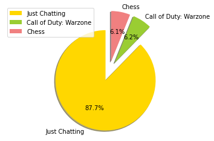

```python
import matplotlib.pyplot as plt

# data to plot
labels = final["MAIN CATEGORY"][0], final["MAIN CATEGORY"][1], final["MAIN CATEGORY"][2]
sizes = [final["TOTAL VIEWS"][0], final["TOTAL VIEWS"][1], final["TOTAL VIEWS"][2]]
colors = ['gold', 'yellowgreen', 'lightcoral']
explode = (0.2, 0.2, 0.2)  # spacing between slices

# plot datas using a pie chart
plt.pie(sizes, explode=explode, labels=labels, colors=colors,
autopct='%1.1f%%', shadow=True, startangle=90)

plt.legend(labels, loc="best")
plt.axis('equal')
plt.show()
```

# **Conclusion**:

It is nice to see, with this simple prediction, how categories influence a streamer's stream. Indeed, it is also important to keep in mind that **Twitch's audience is large** and, with a great probability, a general user follows a stream because the category works with him.

With this data it is possible to carry out a multitude of operations: this data extraction has the aim of categorizing and answering in a pragmatic way the simple question **"which is the most popular category of a streamer?"**.